# Question 2

### Are there any unknown coding differentially expressed transcripts in our data?

We again used the following libraries as well as our data for each cell

```r
library(pheatmap)
library(edgeR)
library(data.table)
library(dplyr)
library(magrittr)

### read in data ###
ESCd1 <- read.csv("/home/pgian1/pred_modl/project/data/csvs/ESCd1_version3.csv") # brain cell 1
ESCd2 <- read.csv("/home/pgian1/pred_modl/project/data/csvs/ESCd2_version3.csv") # brain cell 2
ESCn1 <- read.csv("/home/pgian1/pred_modl/project/data/csvs/ESCn1_version3.csv") # stem cell 1
ESCn2 <- read.csv("/home/pgian1/pred_modl/project/data/csvs/ESCn2_version3.csv") # stem cell 2
```

Then we removed all the non-coding transcripts as well as any transcripts that were already known

```r
### filter out noncoding transcripts - remove unnecesary columns ###
keeps <- c("transcript_id", "chromosome", "TPM")
ESCd1_tpm <- ESCd1[(ESCd1$CNIT_out=="coding"),][keeps]
ESCd2_tpm <- ESCd2[(ESCd2$CNIT_out=="coding"),][keeps]
ESCn1_tpm <- ESCn1[(ESCn1$CNIT_out=="coding"),][keeps]
ESCn2_tpm <- ESCn2[(ESCn2$CNIT_out=="coding"),][keeps]

### filter out known transcripts ###
ESCd1_tpm <- ESCd1_tpm[ESCd1_tpm$transcript_id %like% "MSTRG",]
ESCd2_tpm <- ESCd2_tpm[ESCd2_tpm$transcript_id %like% "MSTRG",]
ESCn1_tpm <- ESCn1_tpm[ESCn1_tpm$transcript_id %like% "MSTRG",]
ESCn2_tpm <- ESCn2_tpm[ESCn2_tpm$transcript_id %like% "MSTRG",]
```

Next we merge all our cell data into a single dataframe.

```r
### merge the nontreated replicates - rename columns ###
n_tpm <- merge(ESCn1_tpm,ESCn2_tpm, by=c("transcript_id", "chromosome"))
colnames(n_tpm)[3] <- "TPM_n1"
colnames(n_tpm)[4] <- "TPM_n2"

### merge the treated replicates - rename columns ###
d_tpm <- merge(ESCd1_tpm,ESCd2_tpm, by=c("transcript_id", "chromosome"))
colnames(d_tpm)[3] <- "TPM_d1"
colnames(d_tpm)[4] <- "TPM_d2"

### merge the samples ###
tpms <- merge(d_tpm, n_tpm, by=c("transcript_id", "chromosome"))
```

Now we remove the ids and chr columns and are left with the TPM values only. Each row is a transcript and each column is the concentration of the transcript in the corresponding cell.

```r
expr_data <- tpms[-c(1, 2)]
head(expr_data)
```

```
##      TPM_d1    TPM_d2   TPM_n1   TPM_n2
## 1  0.000000  3.815762 0.000000 0.000000
## 2 52.485218 33.432259 4.799304 8.423081
## 3  0.024438  0.173734 0.000000 7.748000
## 4  0.172329  0.000000 0.000000 0.000000
## 5  0.000000  0.099100 0.000000 0.383277
## 6 16.085148  5.783655 0.558500 1.823003
```

Similar to question 1, we are testing for differential expression using both a negative binomial generalized linear model and a quasipoisson generalized linear model. We will start with the negative binomial distribution using edgeR as in question 1.

The first step is to create an edgeR object using the expression data

```r
## Convert to an edgeR object
dgeObj_tpm <- DGEList(as.matrix(expr_data))
```

edgeR requires a design matrix when predicting differential expression.

```r
### create matrix ###
design.mat <- cbind(c(0,0,1,1),c(1,1,0,0))
colnames(design.mat) <- c("Brain", "Stem")
print(design.mat)
```

```
##      Brain Stem
## [1,]     0    1
## [2,]     0    1
## [3,]     1    0
## [4,]     1    0
```

To test for DE, we need variance for each transcript. To calculate Variance, we need to calculate dispersion as well as mean TPM for each transcript. The variance is measured as V = mu(1 + dispersion * mu)

```r
### estimate the dispersion for each transcript ###
dgeObj_tpm <- estimateCommonDisp(dgeObj_tpm)
dgeObj_tpm <- estimateGLMTrendedDisp(dgeObj_tpm)
dgeObj_tpm <- estimateTagwiseDisp(dgeObj_tpm)
```

Now we perform a likelihood ratio test to test for differential expression using a negative binomial model generated by the edgeR object

```r
fit_tpm <- glmFit(dgeObj_tpm, design.mat)
lrt.tpm <- glmLRT(fit_tpm, coef=2)

### store results ###
results_tpm <- as.data.frame(topTags(lrt.tpm, n = "Inf"))
results_tpm <- results_tpm[(results_tpm$FDR <= .05),]

### get transcript_ids back using the rownames
tpm_de <- rownames(results_tpm)
de_ids <- tpms[tpm_de,][c("transcript_id")]
```

We visualize our results with a heatmap. There were 11568 DE transcripts detected with the nb-glm. Although these transcripts are identified as differentially expressed between cell type with the negative binomial model, there does not appear to be a strong correlation between cell type as shown by the inconsistantly colored tiles.

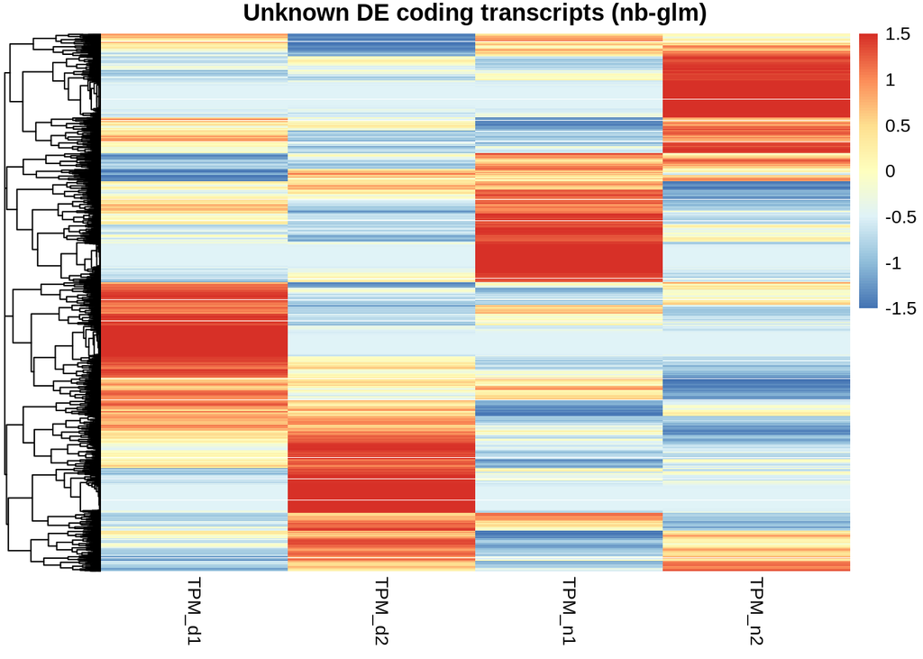

```r
### make a heatmap to visualize results ###
heat <- as.matrix(tpms[tpm_de,][c("TPM_d1","TPM_d2","TPM_n1","TPM_n2")])
heat <- heat %>% set_rownames(de_ids$transcript_id)
pheatmap(heat,
         main = "Unknown DE coding transcripts (nb-glm)",
         scale = "row",
         show_rownames = FALSE,
         cluster_cols = FALSE,
         cluster_rows = TRUE
)
```

Now that we have used a negative binomial model to predict differential expression, we will repeat the experiment using a quasipoisson model.

we start by making a vector that will hold our results

```r
de_pois = vector()
```

We use a for loop to iterate through each transcrtipt and generate a model to show if expression level predicts cell type

```r
for (row in 1:nrow(expr_data)) {

  ### grab each set of expression data per transcript ###
  tran <- expr_data[row,]
  tran <- (as.data.frame(t(as.matrix(tran)))) # transpose our data
  colnames(tran)[1] <- "expression"
  tran$cell_type <- c(1,1,0,0) # add a column for cell type (1=brain, 0=stem)

  ### Ignore cases where TPM is all zeros ###
  check <- list()
  for (i in 1:nrow(tran)) {
    if (tran[i, 1] != 0) {
      check <- append(check, 1)
    }
  }

  ### Make a logistic model to test if expression level predicts cell type
  if (length(check) > 0) {
    model <- glm(expression ~ cell_type, data = tran, family = quasipoisson)
  }

  ### save the p value, if less than .05 than cell type predicts expression ###
  pVal <- (as.matrix(summary(model)$coefficients)[2,4])
  if (as.numeric(pVal) < .05){
    de_pois <- append(de_pois, rownames(expr_data[row,]))
  }
}
```

We again visualize our results with a heatmap. There were 346 DE transcripts detected with the qp-glm. The qp-glm model failed to provide substantial results which indicates that the differential expression is much lower compared to the non-coding transcripts. Our qp-glm detected the same transcrpts as qp-glm, but substantially less.

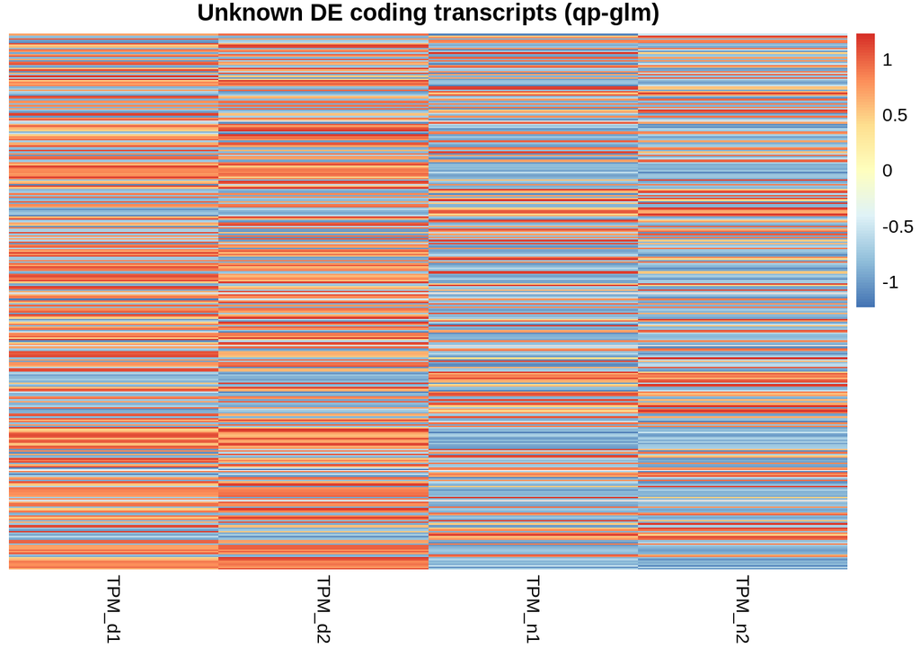

```r
### make a heat map to visualize results ###
de_ids_pois <- tpms[de_pois,][c("transcript_id")]
heat <- as.matrix(tpms[de_pois,][c("TPM_d1","TPM_d2","TPM_n1","TPM_n2")])
heat <- heat %>% set_rownames(de_ids_pois$transcript_id)
pheatmap(heat,
         main = "Unknown DE coding transcripts (qp-glm)",
         scale = "row",
         show_rownames = FALSE,
         cluster_cols = FALSE,
         cluster_rows = FALSE,
         fontsize_row=5
)
```

Based on our results we can conclude that there was less differential expression in the coding as opposed to the non-coding

## Final Outcomes and Analysis

### [Question 1 Report](http://www.itss.brockport.edu/~jlee7/csc435/question1.html)

### [Homepage](http://www.itss.brockport.edu/~jlee7/csc435/index.html)

### [Question 3 Report](http://www.itss.brockport.edu/~jlee7/csc435/question3.html)

### [Question 4 Report](http://www.itss.brockport.edu/~jlee7/csc435/question4.html)

### [Question 5 Report](http://www.itss.brockport.edu/~jlee7/csc435/question5.html)